# STA 363 Project 1

Jason Hou

2022-09-12

# Section 1 Introduction and Data

We are working on the data set that records 5726 children with potential dengue fever, which is a disease that is difficult to diagnose. The data set contains the basic information and measures of the children, including age, sex, BMI(Body Mass Index), height and weight, and 9 features about potential symptoms of dengue fever.The goal of our client is to use this data to establish a efficacious tool as an alternative to predict the dengue fever in children who lacks the access to standard diagnosis test for dengue fever.

| Missing Value |
| --- |
| 0 |

No missing value was detected from the data set.

# Section 2 KNN

## KNN Example

### (1) Demo KNN

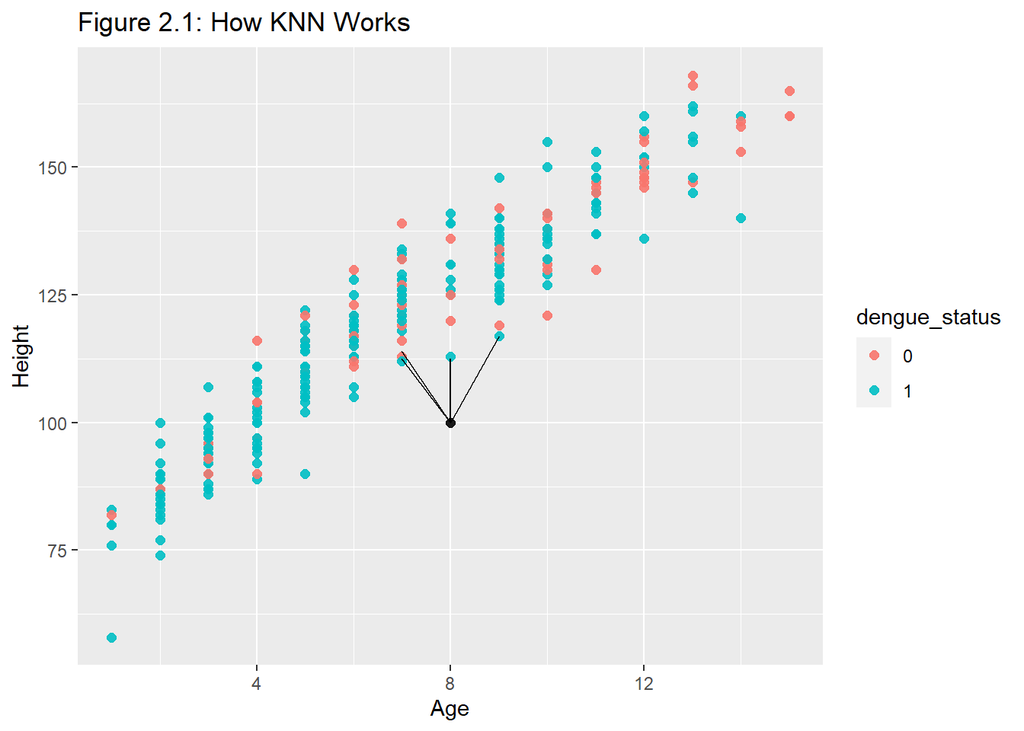

### (2) Split data in to 20% testing and 80% training

We utilized two approaches to predict the dengue status through KNN: (1) Creating a 20% test, 80% training split of the data and use it to for the KNN.(2)Using LOOCV or k-fold Cross Validation. For the first approach, 80% of the 5726 data entries were used for training purpose, and 20% of the data set were used to test the efficacy of the prediction. For the second approach, k-fold Cross Validation was selected, since the relative large size of the data set would lead to a executing time of the prediction. Only Age, DayDisease, Temp and BMI were kept for KNN since KNN can not accept categorical features. Height and Weight were excluded since BMI was calculated from them.

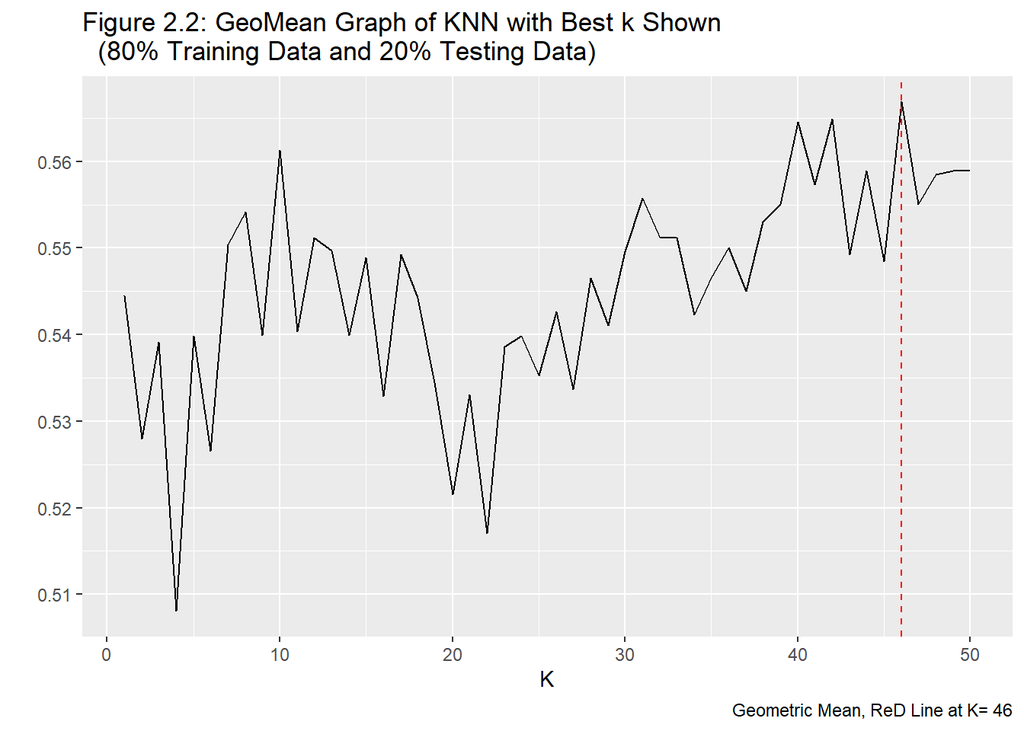

Table 2.1: Confusion Matrix of Dengue Status Prediction(80% Training & 20% Testing )

|  | Not Dengue | Dengue |
| --- | --- | --- |
| 0 | 122 | 87 |
| 1 | 226 | 711 |

From the 80% training, 20% testing approach, we have:

$$Sensitivity = \frac{711}{711+87}\approx
0.891$$
$$Specificity =
\frac{122}{122+226}\approx 0.351$$
$$Accuracy = \frac{122+711}{122+711+226+87}\approx
0.727$$

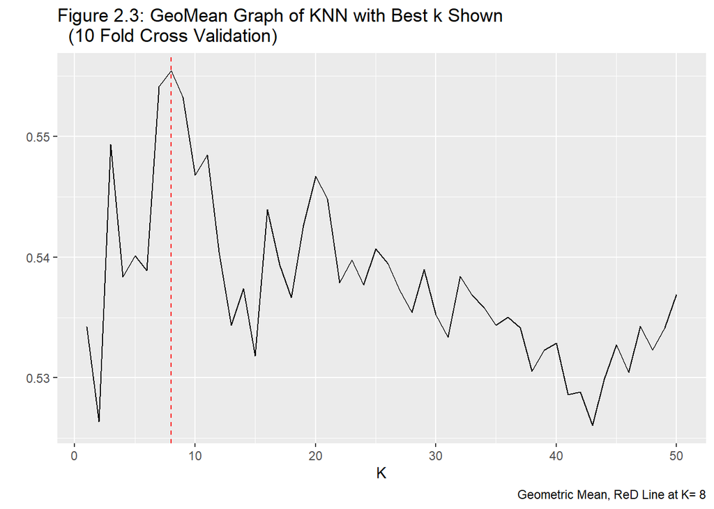

For the k fold Cross Validation, Figure 2.3 shows that k = 8 is the best k value for 10-fold Cross Validation because it provides the largest geometric mean among k values from 1-50, indicating the most ideal balance between the sensitivity and specificity of the prediction.

Table 2.2: Confusion Matrix of Predicting Dengue Status (10 Fold CV & KNN with K = 8)

|  | Not Dengue | Dengue |
| --- | --- | --- |
| 0 | 615 | 597 |
| 1 | 1083 | 3431 |

We have:

$$Sensitivity =
\frac{3431}{3431+597}\approx 0.852$$

$$Specificity =
\frac{615}{615+1083}\approx 0.362$$

$$Accuracy = \frac{615+3431}{5726}\approx
0.71$$

### Table 2.3 Comparison of Predictive Metrics of 2 Types of KNN

[output not shown]

## Section 3 Logistic Regression

### Exploratory Data Analysis

#### Checking Conditions

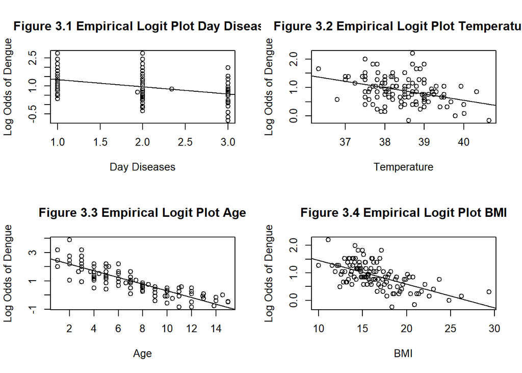

### Checking Interactions

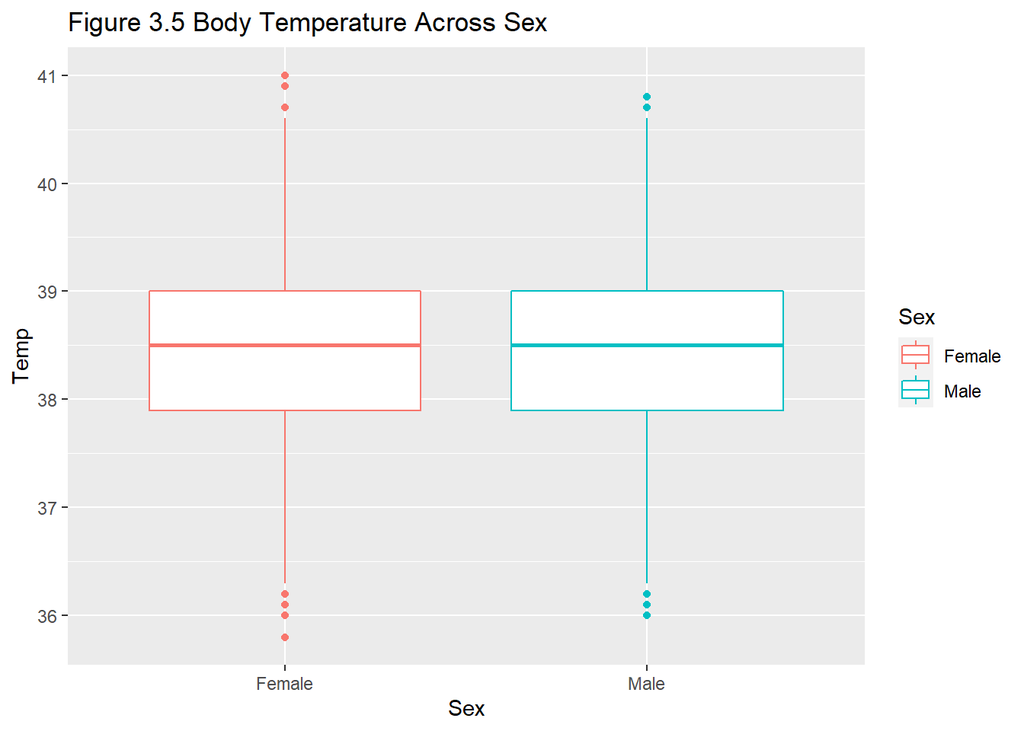

No significant difference on body temperature across sex was found.

[figure not shown]

Figure 3.6 shows that there are more positive dengue fever case in children younger than 8 years old. Also, potential interaction is possible between age and weight of children recorded in the data set.

Table 3.1: Correlation Matrix of Numeric Features

|  | Age | Temp | BMI | Height | Weight |
| --- | --- | --- | --- | --- | --- |
| Age | 1.000 | 0.012 | 0.171 | 0.945 | 0.847 |
| Temp | 0.012 | 1.000 | 0.041 | 0.023 | 0.034 |
| BMI | 0.171 | 0.041 | 1.000 | 0.149 | 0.561 |
| Height | 0.945 | 0.023 | 0.149 | 1.000 | 0.883 |
| Weight | 0.847 | 0.034 | 0.561 | 0.883 | 1.000 |

We suspected that multicolinearity exist between height and weight, as well as Age and height/weight. We also suspect multicolinearity appear between BMI and Height/Weight, since BMI was calculated from these two features. An interaction term between age and weight will be added to deal with the multicolinearity Additionally, vomiting and rash are two of the common symptoms of dengue fever.Thus, age, BMI,weight, temperature will be numeric features selected for the logistic regression model.Sex, Rash and Vomiting will be the categorical features selected for the logistic regression.

```
##
## Call:  glm(formula = Y ~ Sex + Vomiting + Temp + Age * Weight + BMI +
##     Rash + Age + Weight, family = binomial, data = dengue)
##
## Coefficients:
## (Intercept)          Sex     Vomiting         Temp          Age       Weight
##   10.752148    -0.147713     0.364690    -0.205882    -0.213334    -0.090719
##         BMI     RashTRUE   Age:Weight
##    0.033908    -0.920988     0.004634
##
## Degrees of Freedom: 5725 Total (i.e. Null);  5717 Residual
## Null Deviance:       6962
## Residual Deviance: 6112  AIC: 6130
```

### Table 3.2: Coefficient Estimates of Logistic Regression Model Fitted for Prediction

[output not shown]

#### Formatted Confusion Matrix of Prediction with logistic regression

Table 3.2: Confusion Matrix of Predicting Dengue Status (Logistic Regerssion & 10 Fold cv)

|  | Not Dengue | Dengue |
| --- | --- | --- |
| 0 | 939 | 890 |
| 1 | 759 | 3138 |

For prediction through logistic regression, we have

$$Sensitivity =
\frac{3138}{890+3138}\approx 0.779$$

$$Specificity = \frac{939}{759+939}\approx
0.553$$

$$Accuracy = \frac{939+3138}{5726} \approx
0.712$$

## Section 4 Discussion

###### Table 4.1 Comparison of Predictive Metrics of 3 Different Approach For Predicting Dengue Fever

[output not shown]

## Bibliography

CDC. (2021, September 20). Symptoms and treatment. Centers for Disease Control and Prevention. Retrieved September 28, 2022, from https://www.cdc.gov/dengue/symptoms/index.html\